# Carregando Pacotes

### 2 - Utilização do pacote mice.

```r
df[['Age_t_missing']] <- df[['Age']]
```

```r
apply(is.na(df[df[['Sample']] == 'train',c('Pclass','Sex','SibSp','Parch','Fare','Embarked','Cabin','Age_t_missing')]),2,any)
```

**Pclass**

FALSE

**Sex**

FALSE

**SibSp**

FALSE

**Parch**

FALSE

**Fare**

FALSE

**Embarked**

FALSE

**Cabin**

TRUE

**Age_t_missing**

TRUE

```r
dataset <- df[,c('Pclass','Sex','SibSp','Parch','Fare','Embarked','Cabin','Age_t_missing')]
dataset
```

A data.frame: 1309 × 8

| Pclass <ord> | Sex <fct> | SibSp <int> | Parch <int> | Fare <dbl> | Embarked <fct> | Cabin <fct> | Age_t_missing <dbl> |
| --- | --- | --- | --- | --- | --- | --- | --- |
| 3 | male | 1 | 0 | 7.2500 | S | NA | 22 |
| 1 | female | 1 | 0 | 71.2833 | C | AnyCabin | 38 |
| 3 | female | 0 | 0 | 7.9250 | S | NA | 26 |
| 1 | female | 1 | 0 | 53.1000 | S | AnyCabin | 35 |
| 3 | male | 0 | 0 | 8.0500 | S | NA | 35 |
| 3 | male | 0 | 0 | 8.4583 | Q | NA | NA |
| 1 | male | 0 | 0 | 51.8625 | S | AnyCabin | 54 |
| 3 | male | 3 | 1 | 21.0750 | S | NA | 2 |
| ... | ... | ... | ... | ... | ... | ... | ... |
| 1 | female | 1 | 0 | 90.0000 | Q | AnyCabin | 37.0 |
| 3 | female | 0 | 0 | 7.7750 | S | NA | 28.0 |
| 3 | male | 0 | 0 | 8.0500 | S | NA | NA |
| 1 | female | 0 | 0 | 108.9000 | C | AnyCabin | 39.0 |
| 3 | male | 0 | 0 | 7.2500 | S | NA | 38.5 |
| 3 | male | 0 | 0 | 8.0500 | S | NA | NA |
| 3 | male | 1 | 1 | 22.3583 | C | NA | NA |

A matrix: 5 × 9 of type dbl

|  | Pclass | Sex | SibSp | Parch | Fare | Embarked | Age_t_missing | Cabin |  |
| --- | --- | --- | --- | --- | --- | --- | --- | --- | --- |
| 272 | 1 | 1 | 1 | 1 | 1 | 1 | 1 | 1 | 0 |
| 774 | 1 | 1 | 1 | 1 | 1 | 1 | 1 | 0 | 1 |
| 23 | 1 | 1 | 1 | 1 | 1 | 1 | 0 | 1 | 1 |
| 240 | 1 | 1 | 1 | 1 | 1 | 1 | 0 | 0 | 2 |
|  | 0 | 0 | 0 | 0 | 0 | 0 | 263 | 1014 | 1277 |

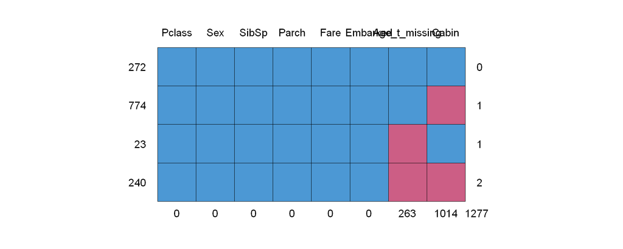

```r
md.pattern(dataset)
```

```r
imputed_Data <- mice(dataset, m=5, maxit = 50, seed = 500)
```

```r
summary(imputed_Data)
```

```
Class: mids
Number of multiple imputations:  5
Imputation methods:
       Pclass           Sex         SibSp         Parch          Fare
           ""            ""            ""            ""            ""
     Embarked         Cabin Age_t_missing
           ""            ""         "pmm"
PredictorMatrix:
         Pclass Sex SibSp Parch Fare Embarked Cabin Age_t_missing
Pclass        0   1     1     1    1        1     0             1
Sex           1   0     1     1    1        1     0             1
SibSp         1   1     0     1    1        1     0             1
Parch         1   1     1     0    1        1     0             1
Fare          1   1     1     1    0        1     0             1
Embarked      1   1     1     1    1        0     0             1
Number of logged events:  1
  it im dep     meth   out
1  0  0     constant Cabin
```

```r
imputed_Data$method %>% print()
```

```
       Pclass           Sex         SibSp         Parch          Fare
           ""            ""            ""            ""            ""
     Embarked         Cabin Age_t_missing
           ""            ""         "pmm"
```

```r
completeData <- mice::complete(imputed_Data)
completeData
```

A data.frame: 1309 × 8

| Pclass <ord> | Sex <fct> | SibSp <int> | Parch <int> | Fare <dbl> | Embarked <fct> | Cabin <fct> | Age_t_missing <dbl> |
| --- | --- | --- | --- | --- | --- | --- | --- |
| 3 | male | 1 | 0 | 7.2500 | S | NA | 22 |
| 1 | female | 1 | 0 | 71.2833 | C | AnyCabin | 38 |
| 3 | female | 0 | 0 | 7.9250 | S | NA | 26 |
| 1 | female | 1 | 0 | 53.1000 | S | AnyCabin | 35 |
| 3 | male | 0 | 0 | 8.0500 | S | NA | 35 |
| 3 | male | 0 | 0 | 8.4583 | Q | NA | 34 |
| 1 | male | 0 | 0 | 51.8625 | S | AnyCabin | 54 |
| 3 | male | 3 | 1 | 21.0750 | S | NA | 2 |
| ... | ... | ... | ... | ... | ... | ... | ... |
| 1 | female | 1 | 0 | 90.0000 | Q | AnyCabin | 37.00 |
| 3 | female | 0 | 0 | 7.7750 | S | NA | 28.00 |
| 3 | male | 0 | 0 | 8.0500 | S | NA | 29.00 |
| 1 | female | 0 | 0 | 108.9000 | C | AnyCabin | 39.00 |
| 3 | male | 0 | 0 | 7.2500 | S | NA | 38.50 |
| 3 | male | 0 | 0 | 8.0500 | S | NA | 44.00 |
| 3 | male | 1 | 1 | 22.3583 | C | NA | 0.17 |

```r
completeData[['Age_t_missing']]
```

1. 22

2. 38

3. 26

4. 35

5. 35

6. 34

7. 54

8. 2

9. 27

10. 14

11. 4

12. 58

13. 20

14. 39

15. 14

16. 55

17. 2

18. 30

19. 31

20. 29

21. 35

22. 34

23. 15

24. 28

25. 8

26. 38

27. 33

28. 19

29. 27

30. 60

31. 40

32. 48

33. 29

34. 66

35. 28

36. 42

37. 9

38. 21

39. 18

40. 14

41. 40

42. 27

43. 32

44. 3

45. 19

46. 24

47. 9

48. 27

49. 38

50. 18

51. 7

52. 21

53. 49

54. 29

55. 65

56. 54

57. 21

58. 28.5

59. 5

60. 11

61. 22

62. 38

63. 45

64. 4

65. 51

66. 24

67. 29

68. 19

69. 17

70. 26

71. 32

72. 16

73. 21

74. 26

75. 32

76. 25

77. 29

78. 24

79. 0.83

80. 30

81. 22

82. 29

83. 27

84. 28

85. 17

86. 33

87. 16

88. 44

89. 23

90. 24

91. 29

92. 20

93. 46

94. 26

95. 59

96. 27

97. 71

98. 23

99. 34

100. 34

101. 28

102. 29

103. 21

104. 33

105. 37

106. 28

107. 21

108. 27

109. 38

110. 36

111. 47

112. 14.5

113. 22

114. 20

115. 17

116. 21

117. 70.5

118. 29

119. 24

120. 2

121. 21

122. 60

123. 32.5

124. 32.5

125. 54

126. 12

127. 29

128. 24

129. 38

130. 45

131. 33

132. 20

133. 47

134. 29

135. 25

136. 23

137. 19

138. 37

139. 16

140. 24

141. 30

142. 22

143. 24

144. 19

145. 18

146. 19

147. 27

148. 9

149. 36.5

150. 42

151. 51

152. 22

153. 55.5

154. 40.5

155. 27

156. 51

157. 16

158. 30

159. 27

160. 10

161. 44

162. 40

163. 26

164. 17

165. 1

166. 9

167. 22

168. 45

169. 47

170. 28

171. 61

172. 4

173. 1

174. 21

175. 56

176. 18

177. 29

178. 50

179. 30

180. 36

181. 11

182. 21

183. 9

184. 1

185. 4

186. 23

187. 4

188. 45

189. 40

190. 36

191. 32

192. 19

193. 19

194. 3

195. 44

196. 58

197. 42

198. 42

199. 44

200. 24

201. ...

202. 50

203. 29

204. 30

205. 21

206. 22

207. 21

208. 53

209. 40

210. 23

211. 60

212. 40.5

213. 36

214. 14

215. 21

216. 21

217. 29

218. 39

219. 20

220. 64

221. 20

222. 18

223. 48

224. 55

225. 45

226. 45

227. 29

228. 4

229. 41

230. 22

231. 42

232. 29

233. 39

234. 0.92

235. 20

236. 27

237. 24

238. 32.5

239. 44

240. 29

241. 28

242. 19

243. 21

244. 36.5

245. 21

246. 29

247. 1

248. 30

249. 29

250. 21

251. 24

252. 18

253. 17

254. 46

255. 42

256. 26

257. 4

258. 16

259. 20

260. 28

261. 40

262. 30

263. 22

264. 23

265. 0.75

266. 29

267. 9

268. 2

269. 36

270. 60

271. 24

272. 36

273. 29

274. 21

275. 30

276. 33

277. 53

278. 36

279. 26

280. 1

281. 2

282. 30

283. 29

284. 32

285. 34.5

286. 43

287. 24

288. 44

289. 64

290. 30

291. 0.83

292. 55

293. 45

294. 18

295. 22

296. 60

297. 37

298. 55

299. 17

300. 57

301. 19

302. 27

303. 22

304. 26

305. 25

306. 26

307. 33

308. 39

309. 23

310. 12

311. 46

312. 29

313. 21

314. 48

315. 39

316. 9

317. 19

318. 27

319. 30

320. 32

321. 39

322. 25

323. 9

324. 18

325. 32

326. 19

327. 58

328. 41

329. 16

330. 26

331. 38

332. 24

333. 31

334. 45

335. 25

336. 18

337. 49

338. 0.17

339. 50

340. 59

341. 27

342. 29

343. 30

344. 14.5

345. 24

346. 31

347. 27

348. 25

349. 48

350. 39

351. 22

352. 45

353. 29

354. 21

355. 31

356. 49

357. 44

358. 54

359. 45

360. 22

361. 21

362. 55

363. 5

364. 40

365. 26

366. 34

367. 19

368. 30

369. 24

370. 24

371. 57

372. 21

373. 6

374. 23

375. 51

376. 13

377. 47

378. 29

379. 18

380. 24

381. 48

382. 22

383. 31

384. 30

385. 38

386. 22

387. 17

388. 43

389. 20

390. 23

391. 50

392. 24

393. 3

394. 44

395. 37

396. 28

397. 29

398. 39

399. 38.5

400. 44

401. 0.17

```r
df[,c('Age')] <- completeData[['Age_t_missing']]
```

```r
apply_binning_by_limites_intervalos(limites_intervalos=lista_Age$limites_intervalos,
                                    dados_entrada=df[df[['Sample']] == 'train',],
                                    nome_variavel='Age')
```

1. 'Nome da lista: lista_Age'

2. **$k**

   11

   **$limites_intervalos**

   1. -Inf

   2. 7.65

   3. 14.9

   4. 22.1

   5. 29.4

   6. 36.6

   7. 43.8

   8. 51.1

   9. 58.3

   10. 65.5

   11. 72.8

   12. Inf

   **$dados_saida**

   1. (14.9,22.1]

   2. (36.6,43.8]

   3. (22.1,29.4]

   4. (29.4,36.6]

   5. (29.4,36.6]

   6. (29.4,36.6]

   7. (51.1,58.3]

   8. [-Inf,7.65]

   9. (22.1,29.4]

   10. (7.65,14.9]

   11. [-Inf,7.65]

   12. (51.1,58.3]

   13. (14.9,22.1]

   14. (36.6,43.8]

   15. (7.65,14.9]

   16. (51.1,58.3]

   17. [-Inf,7.65]

   18. (29.4,36.6]

   19. (29.4,36.6]

   20. (22.1,29.4]

   21. (29.4,36.6]

   22. (29.4,36.6]

   23. (14.9,22.1]

   24. (22.1,29.4]

   25. (7.65,14.9]

   26. (36.6,43.8]

   27. (29.4,36.6]

   28. (14.9,22.1]

   29. (22.1,29.4]

   30. (58.3,65.5]

   31. (36.6,43.8]

   32. (43.8,51.1]

   33. (22.1,29.4]

   34. (65.5,72.8]

   35. (22.1,29.4]

   36. (36.6,43.8]

   37. (7.65,14.9]

   38. (14.9,22.1]

   39. (14.9,22.1]

   40. (7.65,14.9]

   41. (36.6,43.8]

   42. (22.1,29.4]

   43. (29.4,36.6]

   44. [-Inf,7.65]

   45. (14.9,22.1]

   46. (22.1,29.4]

   47. (7.65,14.9]

   48. (22.1,29.4]

   49. (36.6,43.8]

   50. (14.9,22.1]

   51. [-Inf,7.65]

   52. (14.9,22.1]

   53. (43.8,51.1]

   54. (22.1,29.4]

   55. (58.3,65.5]

   56. (51.1,58.3]

   57. (14.9,22.1]

   58. (22.1,29.4]

   59. [-Inf,7.65]

   60. (7.65,14.9]

   61. (14.9,22.1]

   62. (36.6,43.8]

   63. (43.8,51.1]

   64. [-Inf,7.65]

   65. (43.8,51.1]

   66. (22.1,29.4]

   67. (22.1,29.4]

   68. (14.9,22.1]

   69. (14.9,22.1]

   70. (22.1,29.4]

   71. (29.4,36.6]

   72. (14.9,22.1]

   73. (14.9,22.1]

   74. (22.1,29.4]

   75. (29.4,36.6]

   76. (22.1,29.4]

   77. (22.1,29.4]

   78. (22.1,29.4]

   79. [-Inf,7.65]

   80. (29.4,36.6]

   81. (14.9,22.1]

   82. (22.1,29.4]

   83. (22.1,29.4]

   84. (22.1,29.4]

   85. (14.9,22.1]

   86. (29.4,36.6]

   87. (14.9,22.1]

   88. (43.8,51.1]

   89. (22.1,29.4]

   90. (22.1,29.4]

   91. (22.1,29.4]

   92. (14.9,22.1]

   93. (43.8,51.1]

   94. (22.1,29.4]

   95. (58.3,65.5]

   96. (22.1,29.4]

   97. (65.5,72.8]

   98. (22.1,29.4]

   99. (29.4,36.6]

   100. (29.4,36.6]

   101. (22.1,29.4]

   102. (22.1,29.4]

   103. (14.9,22.1]

   104. (29.4,36.6]

   105. (36.6,43.8]

   106. (22.1,29.4]

   107. (14.9,22.1]

   108. (22.1,29.4]

   109. (36.6,43.8]

   110. (29.4,36.6]

   111. (43.8,51.1]

   112. (7.65,14.9]

   113. (14.9,22.1]

   114. (14.9,22.1]

   115. (14.9,22.1]

   116. (14.9,22.1]

   117. (65.5,72.8]

   118. (22.1,29.4]

   119. (22.1,29.4]

   120. [-Inf,7.65]

   121. (14.9,22.1]

   122. (58.3,65.5]

   123. (29.4,36.6]

   124. (29.4,36.6]

   125. (51.1,58.3]

   126. (7.65,14.9]

   127. (22.1,29.4]

   128. (22.1,29.4]

   129. (36.6,43.8]

   130. (43.8,51.1]

   131. (29.4,36.6]

   132. (14.9,22.1]

   133. (43.8,51.1]

   134. (22.1,29.4]

   135. (22.1,29.4]

   136. (22.1,29.4]

   137. (14.9,22.1]

   138. (36.6,43.8]

   139. (14.9,22.1]

   140. (22.1,29.4]

   141. (29.4,36.6]

   142. (14.9,22.1]

   143. (22.1,29.4]

   144. (14.9,22.1]

   145. (14.9,22.1]

   146. (14.9,22.1]

   147. (22.1,29.4]

   148. (7.65,14.9]

   149. (29.4,36.6]

   150. (36.6,43.8]

   151. (43.8,51.1]

   152. (14.9,22.1]

   153. (51.1,58.3]

   154. (36.6,43.8]

   155. (22.1,29.4]

   156. (43.8,51.1]

   157. (14.9,22.1]

   158. (29.4,36.6]

   159. (22.1,29.4]

   160. (7.65,14.9]

   161. (43.8,51.1]

   162. (36.6,43.8]

   163. (22.1,29.4]

   164. (14.9,22.1]

   165. [-Inf,7.65]

   166. (7.65,14.9]

   167. (14.9,22.1]

   168. (43.8,51.1]

   169. (43.8,51.1]

   170. (22.1,29.4]

   171. (58.3,65.5]

   172. [-Inf,7.65]

   173. [-Inf,7.65]

   174. (14.9,22.1]

   175. (51.1,58.3]

   176. (14.9,22.1]

   177. (22.1,29.4]

   178. (43.8,51.1]

   179. (29.4,36.6]

   180. (29.4,36.6]

   181. (7.65,14.9]

   182. (14.9,22.1]

   183. (7.65,14.9]

   184. [-Inf,7.65]

   185. [-Inf,7.65]

   186. (22.1,29.4]

   187. [-Inf,7.65]

   188. (43.8,51.1]

   189. (36.6,43.8]

   190. (29.4,36.6]

   191. (29.4,36.6]

   192. (14.9,22.1]

   193. (14.9,22.1]

   194. [-Inf,7.65]

   195. (43.8,51.1]

   196. (51.1,58.3]

   197. (36.6,43.8]

   198. (36.6,43.8]

   199. (43.8,51.1]

   200. (22.1,29.4]

   201. ...

   202. [-Inf,7.65]

   203. (7.65,14.9]

   204. (22.1,29.4]

   205. (58.3,65.5]

   206. (51.1,58.3]

   207. (43.8,51.1]

   208. (43.8,51.1]

   209. (43.8,51.1]

   210. (36.6,43.8]

   211. (14.9,22.1]

   212. (29.4,36.6]

   213. (14.9,22.1]

   214. (22.1,29.4]

   215. (22.1,29.4]

   216. (36.6,43.8]

   217. (43.8,51.1]

   218. (36.6,43.8]

   219. (14.9,22.1]

   220. (36.6,43.8]

   221. (22.1,29.4]

   222. (14.9,22.1]

   223. (43.8,51.1]

   224. (22.1,29.4]

   225. (51.1,58.3]

   226. (14.9,22.1]

   227. (36.6,43.8]

   228. (22.1,29.4]

   229. (29.4,36.6]

   230. (29.4,36.6]

   231. [-Inf,7.65]

   232. (14.9,22.1]

   233. (29.4,36.6]

   234. (43.8,51.1]

   235. (22.1,29.4]

   236. (14.9,22.1]

   237. (29.4,36.6]

   238. (22.1,29.4]

   239. (22.1,29.4]

   240. (22.1,29.4]

   241. (22.1,29.4]

   242. (7.65,14.9]

   243. (29.4,36.6]

   244. (22.1,29.4]

   245. (22.1,29.4]

   246. (22.1,29.4]

   247. (43.8,51.1]

   248. (29.4,36.6]

   249. (22.1,29.4]

   250. (22.1,29.4]

   251. (22.1,29.4]

   252. (29.4,36.6]

   253. (14.9,22.1]

   254. (22.1,29.4]

   255. (29.4,36.6]

   256. (65.5,72.8]

   257. (14.9,22.1]

   258. (29.4,36.6]

   259. (14.9,22.1]

   260. (29.4,36.6]

   261. [-Inf,7.65]

   262. [-Inf,7.65]

   263. (29.4,36.6]

   264. (22.1,29.4]

   265. (43.8,51.1]

   266. [-Inf,7.65]

   267. (22.1,29.4]

   268. (14.9,22.1]

   269. (29.4,36.6]

   270. (29.4,36.6]

   271. (22.1,29.4]

   272. (36.6,43.8]

   273. (14.9,22.1]

   274. (29.4,36.6]

   275. (14.9,22.1]

   276. (43.8,51.1]

   277. (14.9,22.1]

   278. (29.4,36.6]

   279. (7.65,14.9]

   280. (29.4,36.6]

   281. (22.1,29.4]

   282. (43.8,51.1]

   283. (51.1,58.3]

   284. (14.9,22.1]

   285. (51.1,58.3]

   286. (14.9,22.1]

   287. (22.1,29.4]

   288. [-Inf,7.65]

   289. (36.6,43.8]

   290. (36.6,43.8]

   291. (7.65,14.9]

   292. (14.9,22.1]

   293. (22.1,29.4]

   294. (22.1,29.4]

   295. (22.1,29.4]

   296. (22.1,29.4]

   297. (14.9,22.1]

   298. (7.65,14.9]

   299. [-Inf,7.65]

   300. (43.8,51.1]

   301. (22.1,29.4]

   302. (14.9,22.1]

   303. (7.65,14.9]

   304. (14.9,22.1]

   305. (22.1,29.4]

   306. (36.6,43.8]

   307. (43.8,51.1]

   308. (29.4,36.6]

   309. (29.4,36.6]

   310. (29.4,36.6]

   311. (29.4,36.6]

   312. (29.4,36.6]

   313. (7.65,14.9]

   314. [-Inf,7.65]

   315. (22.1,29.4]

   316. (29.4,36.6]

   317. (36.6,43.8]

   318. (14.9,22.1]

   319. (36.6,43.8]

   320. (29.4,36.6]

   321. (22.1,29.4]

   322. (36.6,43.8]

   323. (29.4,36.6]

   324. [-Inf,7.65]

   325. (29.4,36.6]

   326. (51.1,58.3]

   327. (22.1,29.4]

   328. (29.4,36.6]

   329. (36.6,43.8]

   330. (7.65,14.9]

   331. (51.1,58.3]

   332. (22.1,29.4]

   333. (36.6,43.8]

   334. (22.1,29.4]

   335. [-Inf,7.65]

   336. (36.6,43.8]

   337. (36.6,43.8]

   338. [-Inf,7.65]

   339. (36.6,43.8]

   340. (58.3,65.5]

   341. (14.9,22.1]

   342. [-Inf,7.65]

   343. (14.9,22.1]

   344. (22.1,29.4]

   345. (14.9,22.1]

   346. (36.6,43.8]

   347. (14.9,22.1]

   348. (22.1,29.4]

   349. (29.4,36.6]

   350. (14.9,22.1]

   351. (14.9,22.1]

   352. (14.9,22.1]

   353. (29.4,36.6]

   354. (29.4,36.6]

   355. (14.9,22.1]

   356. (36.6,43.8]

   357. (7.65,14.9]

   358. (29.4,36.6]

   359. (22.1,29.4]

   360. (58.3,65.5]

   361. [-Inf,7.65]

   362. (72.8, Inf]

   363. (7.65,14.9]

   364. (14.9,22.1]

   365. (43.8,51.1]

   366. (14.9,22.1]

   367. (43.8,51.1]

   368. (43.8,51.1]

   369. (22.1,29.4]

   370. (14.9,22.1]

   371. (36.6,43.8]

   372. (14.9,22.1]

   373. (43.8,51.1]

   374. (7.65,14.9]

   375. (22.1,29.4]

   376. (36.6,43.8]

   377. (22.1,29.4]

   378. (29.4,36.6]

   379. (22.1,29.4]

   380. [-Inf,7.65]

   381. (22.1,29.4]

   382. (43.8,51.1]

   383. (29.4,36.6]

   384. (43.8,51.1]

   385. (22.1,29.4]

   386. (14.9,22.1]

   387. (14.9,22.1]

   388. (14.9,22.1]

   389. (22.1,29.4]

   390. (51.1,58.3]

   391. (22.1,29.4]

   392. (29.4,36.6]

   393. (14.9,22.1]

   394. (22.1,29.4]

   395. (22.1,29.4]

   396. (36.6,43.8]

   397. (22.1,29.4]

   398. (14.9,22.1]

   399. (36.6,43.8]

   400. (22.1,29.4]

   401. (29.4,36.6]

   **Levels**:**

   1. '[-Inf,7.65]'

   2. '(7.65,14.9]'

   3. '(14.9,22.1]'

   4. '(22.1,29.4]'

   5. '(29.4,36.6]'

   6. '(36.6,43.8]'

   7. '(43.8,51.1]'

   8. '(51.1,58.3]'

   9. '(58.3,65.5]'

   10. '(65.5,72.8]'

   11. '(72.8, Inf]'

   12. NA

```r
df[df[['Sample']] == 'train','Age_t_missing_categ'] <- lista_Age[['dados_saida']]
```

```r
calcula_tab_frequencia(tabela_de_entrada=df[df[['Sample']] == 'train',],
                        nome_variavel='Age_t_missing_categ')
```

1. 'Nome da tabela abaixo: table_count_propAge_t_missing_categ'

2. A data.frame: 12 × 5

   | Category <fct> | Frequency <int> | Percentage <table> | Cumulative.Frequency <int> | Cumulative.Percentage <dbl> |
   | --- | --- | --- | --- | --- |
   | [-Inf,7.65] | 55 | 6.17 | 55 | 6.17 |
   | (7.65,14.9] | 46 | 5.16 | 101 | 11.34 |
   | (14.9,22.1] | 172 | 19.30 | 273 | 30.64 |
   | (22.1,29.4] | 218 | 24.47 | 491 | 55.11 |
   | (29.4,36.6] | 159 | 17.85 | 650 | 72.95 |
   | (36.6,43.8] | 87 | 9.76 | 737 | 82.72 |
   | (43.8,51.1] | 85 | 9.54 | 822 | 92.26 |
   | (51.1,58.3] | 33 | 3.70 | 855 | 95.96 |
   | (58.3,65.5] | 28 | 3.14 | 883 | 99.10 |
   | (65.5,72.8] | 6 | 0.67 | 889 | 99.78 |
   | (72.8, Inf] | 2 | 0.22 | 891 | 100.00 |
   | NA | 0 | 0.00 | 891 | 100.00 |

1. 'Nome do gráfico: gg_count_propAge_t_missing_categ'

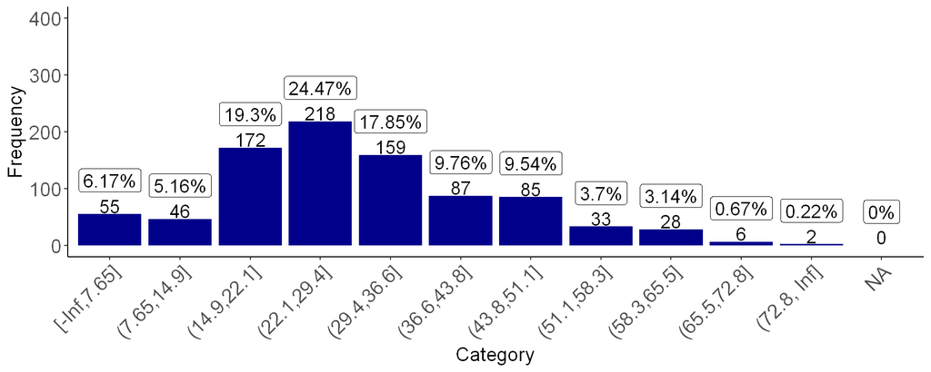

```r
grafico_tab_frequencia3(table_count_prop=table_count_propAge_t_missing_categ,
                       nome_variavel='Age_t_missing_categ',
                       cor_grafico='darkblue',
                       size=5,
                       angle=45,tx1=0.8,tx2=1.2,
                       legend=TRUE,percentage=TRUE,count=TRUE)
gg_count_propAge_t_missing_categ <- gg_count_propAge_t_missing_categ + theme(axis.text=element_text(size=15),
                                                            axis.title=element_text(size=15)) +
                                                            coord_cartesian(ylim=c(0,400))
gg_count_propAge_t_missing_categ
```

Essa aplicação gerou novos dados para os indivíduos que não tinham as suas idades preenchidas. A utilização do pacote mice permitiu que isso fosse feito considerando o perfil de cada indivíduo, o que deixou o novo histograma com uma distribuição mais simétrica. Portanto, essa ténica foi escolhida como tratamento de dados para a variável Age.

```r
df <- select(df,-c('Age_t_missing','Age_t_missing_categ')) # drop columns Age_t_missing, Age_t_missing_categ
```

# Cria tabelas finais (com dados tratados)

```r
saveRDS(df,file="df_tidy.rda")
saveRDS(df[df[['Sample']] == 'train',],
        file="train_tidy.rda")
saveRDS(df[df[['Sample']] == 'test',],
        file="test_tidy.rda")
```

```r
df_tidy <- readRDS(file="df_tidy.rda")
train_tidy <- readRDS(file="train_tidy.rda")
test_tidy <- readRDS(file="test_tidy.rda")
```

# Tabela de Metadados (Foco em Modelagem Estatística/Machine Learning)

```r
vector_vars_drop <- c('PassengerId','Name','Ticket','Sample')
```

```r
tabela_metadados(tabela_de_entrada = train_tidy,
                 sufixo_da_tabela_saida = 'train_tidy',
                 vector_vars_drop = vector_vars_drop)
```

1. 'Nome da tabela de entrada: train_tidy'

2. 'Dim da tabela de entrada: (891,13)'

3. 'Atributos a serem ignorados no futuro: c("PassengerId", "Name", "Ticket", "Sample")'

4. 'Nome da tabela abaixo: metadata_table_train_tidy'

5. A data.frame: 13 × 10

   | index <int> | columns <chr> | class <chr> | nunique <int> | nunique_with_na <int> | na_value_count <int> | p_na_value_count <dbl> | p_mode_value_natoo <dbl> | p_mode_value_notna <dbl> | drop <lgl> |
   | --- | --- | --- | --- | --- | --- | --- | --- | --- | --- |
   | 1 | PassengerId | factor | 891 | 891 | 0 | 0.000 | 0.00112 | 0.00112 | TRUE |
   | 2 | Survived | factor | 2 | 2 | 0 | 0.000 | 0.61616 | 0.61616 | FALSE |
   | 3 | Pclass | ordered; factor | 3 | 3 | 0 | 0.000 | 0.55107 | 0.55107 | FALSE |
   | 4 | Name | character | 891 | 891 | 0 | 0.000 | 0.00112 | 0.00112 | TRUE |
   | 5 | Sex | factor | 2 | 2 | 0 | 0.000 | 0.64759 | 0.64759 | FALSE |
   | 6 | Age | numeric | 89 | 89 | 0 | 0.000 | 0.05724 | 0.05724 | FALSE |
   | 7 | SibSp | integer | 7 | 7 | 0 | 0.000 | 0.68238 | 0.68238 | FALSE |
   | 8 | Parch | integer | 7 | 7 | 0 | 0.000 | 0.76094 | 0.76094 | FALSE |
   | 9 | Ticket | character | 681 | 681 | 0 | 0.000 | 0.00786 | 0.00786 | TRUE |
   | 10 | Fare | numeric | 248 | 248 | 0 | 0.000 | 0.04826 | 0.04826 | FALSE |
   | 11 | Cabin | factor | 1 | 2 | 687 | 0.771 | 0.77104 | 1.00000 | FALSE |
   | 12 | Embarked | factor | 3 | 3 | 0 | 0.000 | 0.72503 | 0.72503 | FALSE |
   | 13 | Sample | factor | 1 | 1 | 0 | 0.000 | 1.00000 | 1.00000 | TRUE |

```r
tabela_metadados(tabela_de_entrada = test_tidy,
                 sufixo_da_tabela_saida = 'test_tidy',
                 vector_vars_drop = vector_vars_drop)
```

1. 'Nome da tabela de entrada: test_tidy'

2. 'Dim da tabela de entrada: (418,13)'

3. 'Atributos a serem ignorados no futuro: c("PassengerId", "Name", "Ticket", "Sample")'

4. 'Nome da tabela abaixo: metadata_table_test_tidy'

5. A data.frame: 13 × 10

   | index <int> | columns <chr> | class <chr> | nunique <int> | nunique_with_na <int> | na_value_count <int> | p_na_value_count <dbl> | p_mode_value_natoo <dbl> | p_mode_value_notna <dbl> | drop <lgl> |
   | --- | --- | --- | --- | --- | --- | --- | --- | --- | --- |
   | 1 | PassengerId | factor | 418 | 418 | 0 | 0.000 | 0.00239 | 0.00239 | TRUE |
   | 2 | Survived | factor | 0 | 1 | 418 | 1.000 | 1.00000 | Inf | FALSE |
   | 3 | Pclass | ordered; factor | 3 | 3 | 0 | 0.000 | 0.52153 | 0.52153 | FALSE |
   | 4 | Name | character | 418 | 418 | 0 | 0.000 | 0.00239 | 0.00239 | TRUE |
   | 5 | Sex | factor | 2 | 2 | 0 | 0.000 | 0.63636 | 0.63636 | FALSE |
   | 6 | Age | numeric | 80 | 80 | 0 | 0.000 | 0.05263 | 0.05263 | FALSE |
   | 7 | SibSp | integer | 7 | 7 | 0 | 0.000 | 0.67703 | 0.67703 | FALSE |
   | 8 | Parch | integer | 8 | 8 | 0 | 0.000 | 0.77512 | 0.77512 | FALSE |
   | 9 | Ticket | character | 363 | 363 | 0 | 0.000 | 0.01196 | 0.01196 | TRUE |
   | 10 | Fare | numeric | 169 | 169 | 0 | 0.000 | 0.05024 | 0.05024 | FALSE |
   | 11 | Cabin | factor | 1 | 2 | 327 | 0.782 | 0.78230 | 1.00000 | FALSE |
   | 12 | Embarked | factor | 3 | 3 | 0 | 0.000 | 0.64593 | 0.64593 | FALSE |
   | 13 | Sample | factor | 1 | 1 | 0 | 0.000 | 1.00000 | 1.00000 | TRUE |

```r
tabela_metadados(tabela_de_entrada = df_tidy,
                 sufixo_da_tabela_saida = 'df_tidy',
                 vector_vars_drop = vector_vars_drop)
```

1. 'Nome da tabela de entrada: df_tidy'

2. 'Dim da tabela de entrada: (1309,13)'

3. 'Atributos a serem ignorados no futuro: c("PassengerId", "Name", "Ticket", "Sample")'

4. 'Nome da tabela abaixo: metadata_table_df_tidy'

5. A data.frame: 13 × 10

   | index <int> | columns <chr> | class <chr> | nunique <int> | nunique_with_na <int> | na_value_count <int> | p_na_value_count <dbl> | p_mode_value_natoo <dbl> | p_mode_value_notna <dbl> | drop <lgl> |
   | --- | --- | --- | --- | --- | --- | --- | --- | --- | --- |
   | 1 | PassengerId | factor | 1309 | 1309 | 0 | 0.000 | 0.000764 | 0.000764 | TRUE |
   | 2 | Survived | factor | 2 | 3 | 418 | 0.319 | 0.419404 | 0.616162 | FALSE |
   | 3 | Pclass | ordered; factor | 3 | 3 | 0 | 0.000 | 0.541635 | 0.541635 | FALSE |
   | 4 | Name | character | 1307 | 1307 | 0 | 0.000 | 0.001528 | 0.001528 | TRUE |
   | 5 | Sex | factor | 2 | 2 | 0 | 0.000 | 0.644003 | 0.644003 | FALSE |
   | 6 | Age | numeric | 98 | 98 | 0 | 0.000 | 0.055768 | 0.055768 | FALSE |
   | 7 | SibSp | integer | 7 | 7 | 0 | 0.000 | 0.680672 | 0.680672 | FALSE |
   | 8 | Parch | integer | 8 | 8 | 0 | 0.000 | 0.765470 | 0.765470 | FALSE |
   | 9 | Ticket | character | 929 | 929 | 0 | 0.000 | 0.008403 | 0.008403 | TRUE |
   | 10 | Fare | numeric | 281 | 281 | 0 | 0.000 | 0.046600 | 0.046600 | FALSE |
   | 11 | Cabin | factor | 1 | 2 | 1014 | 0.775 | 0.774637 | 1.000000 | FALSE |
   | 12 | Embarked | factor | 3 | 3 | 0 | 0.000 | 0.699771 | 0.699771 | FALSE |
   | 13 | Sample | factor | 2 | 2 | 0 | 0.000 | 0.680672 | 0.680672 | TRUE |

Retira as variáveis com drop == TRUE

```r
df_tidy_ml <- df_tidy[,metadata_table_df_tidy[!metadata_table_df_tidy[['drop']],'columns']]
train_tidy_ml <- train_tidy[,metadata_table_train_tidy[!metadata_table_train_tidy[['drop']],'columns']]
test_tidy_ml <- test_tidy[,metadata_table_test_tidy[!metadata_table_test_tidy[['drop']],'columns']]
```

Transforma os NA das covariáveis em strings 'NA'

```r
columns_add_missing_level <- colnames(df_tidy_ml)[apply(is.na(df_tidy_ml),2,any)]
columns_add_missing_level
```

1. 'Survived'

2. 'Cabin'

Survived

```r
levels(df_tidy_ml[['Survived']]) <- c('bad','good') # factor(c('1','0'))
levels(train_tidy_ml[['Survived']]) <- c('bad','good') # factor(c('1','0'))
levels(train_tidy_ml[['Survived']]) <- c('bad','good') # factor(c('1','0'))
```

Cabin

```r
for(j in 2:length(columns_add_missing_level)){
    df_tidy_ml[[columns_add_missing_level[j]]] <- addNA(df_tidy_ml[[columns_add_missing_level[j]]])
    levels(df_tidy_ml[[columns_add_missing_level[j]]])[length(levels(df_tidy_ml[[columns_add_missing_level[j]]]))] <- 'NA'

    train_tidy_ml[[columns_add_missing_level[j]]] <- addNA(train_tidy_ml[[columns_add_missing_level[j]]])
    levels(train_tidy_ml[[columns_add_missing_level[j]]])[length(levels(train_tidy_ml[[columns_add_missing_level[j]]]))] <- 'NA'

    test_tidy_ml[[columns_add_missing_level[j]]] <- addNA(test_tidy_ml[[columns_add_missing_level[j]]])
    levels(test_tidy_ml[[columns_add_missing_level[j]]])[length(levels(test_tidy_ml[[columns_add_missing_level[j]]]))] <- 'NA'
}
```

```r
str(train_tidy_ml)
```

```
'data.frame':	891 obs. of  9 variables:
 $ Survived: Factor w/ 2 levels "bad","good": 2 1 1 1 2 2 2 2 1 1 ...
 $ Pclass  : Ord.factor w/ 3 levels "1"<"2"<"3": 3 1 3 1 3 3 1 3 3 2 ...
 $ Sex     : Factor w/ 2 levels "female","male": 2 1 1 1 2 2 2 2 1 1 ...
 $ Age     : num  22 38 26 35 35 34 54 2 27 14 ...
 $ SibSp   : int  1 1 0 1 0 0 0 3 0 1 ...
 $ Parch   : int  0 0 0 0 0 0 0 1 2 0 ...
 $ Fare    : num  7.25 71.28 7.92 53.1 8.05 ...
 $ Cabin   : Factor w/ 2 levels "AnyCabin","NA": 2 1 2 1 2 2 1 2 2 2 ...
 $ Embarked: Factor w/ 3 levels "C","Q","S": 3 1 3 3 3 2 3 3 3 1 ...
```

```r
str(test_tidy_ml)
```

```
'data.frame':	418 obs. of  9 variables:
 $ Survived: Factor w/ 2 levels "1","0": NA NA NA NA NA NA NA NA NA NA ...
 $ Pclass  : Ord.factor w/ 3 levels "1"<"2"<"3": 3 3 2 3 3 3 3 2 3 3 ...
 $ Sex     : Factor w/ 2 levels "female","male": 2 1 2 2 1 2 1 2 1 2 ...
 $ Age     : num  34.5 47 62 27 22 14 30 26 18 21 ...
 $ SibSp   : int  0 1 0 0 1 0 0 1 0 2 ...
 $ Parch   : int  0 0 0 0 1 0 0 1 0 0 ...
 $ Fare    : num  7.83 7 9.69 8.66 12.29 ...
 $ Cabin   : Factor w/ 2 levels "AnyCabin","NA": 2 2 2 2 2 2 2 2 2 2 ...
 $ Embarked: Factor w/ 3 levels "C","Q","S": 2 3 2 3 3 3 2 3 1 3 ...
```

```r
str(df_tidy_ml)
```

```
'data.frame':	1309 obs. of  9 variables:
 $ Survived: Factor w/ 2 levels "bad","good": 2 1 1 1 2 2 2 2 1 1 ...
 $ Pclass  : Ord.factor w/ 3 levels "1"<"2"<"3": 3 1 3 1 3 3 1 3 3 2 ...
 $ Sex     : Factor w/ 2 levels "female","male": 2 1 1 1 2 2 2 2 1 1 ...
 $ Age     : num  22 38 26 35 35 34 54 2 27 14 ...
 $ SibSp   : int  1 1 0 1 0 0 0 3 0 1 ...
 $ Parch   : int  0 0 0 0 0 0 0 1 2 0 ...
 $ Fare    : num  7.25 71.28 7.92 53.1 8.05 ...
 $ Cabin   : Factor w/ 2 levels "AnyCabin","NA": 2 1 2 1 2 2 1 2 2 2 ...
 $ Embarked: Factor w/ 3 levels "C","Q","S": 3 1 3 3 3 2 3 3 3 1 ...
```

```r
#saveRDS(df_tidy_ml,file="df_tidy_ml.rda")
saveRDS(train_tidy_ml,
        file="train_tidy_ml.rda")
saveRDS(test_tidy_ml,
        file="test_tidy_ml.rda")
```

```r
#df_tidy_ml <- readRDS(file="df_tidy_ml.rda")
train_tidy_ml <- readRDS(file="train_tidy_ml.rda")
test_tidy_ml <- readRDS(file="test_tidy_ml.rda")
```

# Feature Selection

```r
fit1 <- glm(Survived ~ .,  data = train_tidy_ml,
            family = binomial(link = "logit"))
summary(fit1)
```

```
Call:
glm(formula = Survived ~ ., family = binomial(link = "logit"),
    data = train_tidy_ml)

Deviance Residuals:
   Min      1Q  Median      3Q     Max
-2.473  -0.619   0.405   0.621   2.591

Coefficients:
            Estimate Std. Error z value Pr(>|z|)
(Intercept) -3.50451    0.44030   -7.96  1.7e-15 ***
Pclass.L     1.02000    0.28527    3.58  0.00035 ***
Pclass.Q     0.37891    0.20833    1.82  0.06895 .
Sexmale      2.70663    0.20169   13.42  < 2e-16 ***
Age          0.03195    0.00731    4.37  1.2e-05 ***
SibSp        0.33318    0.10882    3.06  0.00220 **
Parch        0.10854    0.11883    0.91  0.36103
Fare        -0.00207    0.00247   -0.84  0.40025
CabinNA      0.90103    0.33306    2.71  0.00682 **
EmbarkedQ    0.02356    0.38134    0.06  0.95073
 [ reached getOption("max.print") -- omitted 1 row ]
---
Signif. codes:  0 '***' 0.001 '**' 0.01 '*' 0.05 '.' 0.1 ' ' 1

(Dispersion parameter for binomial family taken to be 1)

    Null deviance: 1186.66  on 890  degrees of freedom
Residual deviance:  781.28  on 880  degrees of freedom
AIC: 803.3

Number of Fisher Scoring iterations: 5
```

```r
## Selecionando covariáveis: Método stepwise
fit1_featureselection <- step(fit1, direction = "both")
print(fit1_featureselection)
```

```
Start:  AIC=803
Survived ~ Pclass + Sex + Age + SibSp + Parch + Fare + Cabin +
    Embarked

           Df Deviance  AIC
- Fare      1      782  802
- Parch     1      782  802
<none>             781  803
- Embarked  2      786  804
- Cabin     1      789  809
- SibSp     1      792  812
- Age       1      801  821
- Pclass    2      811  829
- Sex       1     1007 1027

Step:  AIC=802
Survived ~ Pclass + Sex + Age + SibSp + Parch + Cabin + Embarked

           Df Deviance  AIC
- Parch     1      783  801
<none>             782  802
- Embarked  2      787  803
+ Fare      1      781  803
- Cabin     1      790  808
- SibSp     1      792  810
- Age       1      803  821
- Pclass    2      817  833
- Sex       1     1011 1029

Step:  AIC=801
Survived ~ Pclass + Sex + Age + SibSp + Cabin + Embarked

           Df Deviance  AIC
<none>             783  801
- Embarked  2      788  802
+ Parch     1      782  802
+ Fare      1      782  802
- Cabin     1      790  806
- SibSp     1      796  812
- Age       1      803  819
- Pclass    2      818  832
- Sex       1     1017 1033

Call:  glm(formula = Survived ~ Pclass + Sex + Age + SibSp + Cabin +
    Embarked, family = binomial(link = "logit"), data = train_tidy_ml)

Coefficients:
(Intercept)     Pclass.L     Pclass.Q      Sexmale          Age        SibSp
    -3.5417       1.1298       0.3393       2.6808       0.0322       0.3453
    CabinNA    EmbarkedQ    EmbarkedS
     0.8836       0.0121       0.4781

Degrees of Freedom: 890 Total (i.e. Null);  882 Residual
Null Deviance:	    1190
Residual Deviance: 783 	AIC: 801
```

```r
fit1_featureselection %>% str()
```

```
List of 31
 $ coefficients     : Named num [1:9] -3.5417 1.1298 0.3393 2.6808 0.0322 ...
  ..- attr(*, "names")= chr [1:9] "(Intercept)" "Pclass.L" "Pclass.Q" "Sexmale" ...
 $ residuals        : Named num [1:891] 1.08 -1.07 -1.67 -1.11 1.08 ...
  ..- attr(*, "names")= chr [1:891] "1" "2" "3" "4" ...
 $ fitted.values    : Named num [1:891] 0.9236 0.067 0.4 0.0952 0.9286 ...
  ..- attr(*, "names")= chr [1:891] "1" "2" "3" "4" ...
 $ effects          : Named num [1:891] -4.398 5.104 -0.646 13.247 -3.837 ...
  ..- attr(*, "names")= chr [1:891] "(Intercept)" "Pclass.L" "Pclass.Q" "Sexmale" ...
 $ R                : num [1:9, 1:9] -11.2 0 0 0 0 ...
  ..- attr(*, "dimnames")=List of 2
  .. ..$ : chr [1:9] "(Intercept)" "Pclass.L" "Pclass.Q" "Sexmale" ...
  .. ..$ : chr [1:9] "(Intercept)" "Pclass.L" "Pclass.Q" "Sexmale" ...
 $ rank             : int 9
 $ qr               :List of 5
  ..$ qr   : num [1:891, 1:9] -11.1672 0.0224 0.0439 0.0263 0.0231 ...
  .. ..- attr(*, "dimnames")=List of 2
  .. .. ..$ : chr [1:891] "1" "2" "3" "4" ...
  .. .. ..$ : chr [1:9] "(Intercept)" "Pclass.L" "Pclass.Q" "Sexmale" ...
  ..$ rank : int 9
  ..$ qraux: num [1:9] 1.02 1.03 1.02 1.04 1.02 ...
  ..$ pivot: int [1:9] 1 2 3 4 5 6 7 8 9
  ..$ tol  : num 1e-11
  ..- attr(*, "class")= chr "qr"
 $ family           :List of 12
  ..$ family    : chr "binomial"
  ..$ link      : chr "logit"
  ..$ linkfun   :function (mu)
  ..$ linkinv   :function (eta)
  ..$ variance  :function (mu)
  ..$ dev.resids:function (y, mu, wt)
  ..$ aic       :function (y, n, mu, wt, dev)
  ..$ mu.eta    :function (eta)
  ..$ initialize: language {     if (NCOL(y) == 1) { ...
  ..$ validmu   :function (mu)
  ..$ valideta  :function (eta)
  ..$ simulate  :function (object, nsim)
  ..- attr(*, "class")= chr "family"
 $ linear.predictors: Named num [1:891] 2.492 -2.633 -0.405 -2.252 2.565 ...
  ..- attr(*, "names")= chr [1:891] "1" "2" "3" "4" ...
```

[output cut: 73 more lines]

```
  ..$ Embarked: chr "contr.treatment"
 $ xlevels          :List of 4
  ..$ Pclass  : chr [1:3] "1" "2" "3"
  ..$ Sex     : chr [1:2] "female" "male"
  ..$ Cabin   : chr [1:2] "AnyCabin" "NA"
  ..$ Embarked: chr [1:3] "C" "Q" "S"
 $ anova            :'data.frame':	3 obs. of  6 variables:
  ..$ Step      : 'AsIs' chr [1:3] "" "- Fare" "- Parch"
  ..$ Df        : num [1:3] NA 1 1
  ..$ Deviance  : num [1:3] NA 0.766 0.57
  ..$ Resid. Df : num [1:3] 880 881 882
  ..$ Resid. Dev: num [1:3] 781 782 783
  ..$ AIC       : num [1:3] 803 802 801
  ..- attr(*, "heading")= chr [1:7] "Stepwise Model Path \nAnalysis of Deviance Table" "\nInitial Model:" "Survived ~ Pclass + Sex + Age + SibSp + Parch + Fare + Cabin + " "    Embarked" ...
 - attr(*, "class")= chr [1:2] "glm" "lm"
```

```r
fit1_featureselection$call
```

```
glm(formula = Survived ~ Pclass + Sex + Age + SibSp + Cabin +
    Embarked, family = binomial(link = "logit"), data = train_tidy_ml)
```

```r
fit1_featureselection$model %>% colnames()
```

1. 'Survived'

2. 'Pclass'

3. 'Sex'

4. 'Age'

5. 'SibSp'

6. 'Cabin'

7. 'Embarked'

```r
summary(fit1_featureselection)
```

```
Call:
glm(formula = Survived ~ Pclass + Sex + Age + SibSp + Cabin +
    Embarked, family = binomial(link = "logit"), data = train_tidy_ml)

Deviance Residuals:
   Min      1Q  Median      3Q     Max
-2.437  -0.619   0.402   0.617   2.588

Coefficients:
            Estimate Std. Error z value Pr(>|z|)
(Intercept) -3.54174    0.41253   -8.59  < 2e-16 ***
Pclass.L     1.12976    0.26055    4.34  1.5e-05 ***
Pclass.Q     0.33934    0.20357    1.67  0.09552 .
Sexmale      2.68076    0.19599   13.68  < 2e-16 ***
Age          0.03220    0.00728    4.42  9.8e-06 ***
SibSp        0.34528    0.10373    3.33  0.00087 ***
CabinNA      0.88361    0.32844    2.69  0.00714 **
EmbarkedQ    0.01212    0.37819    0.03  0.97443
EmbarkedS    0.47814    0.23616    2.02  0.04291 *
---
Signif. codes:  0 '***' 0.001 '**' 0.01 '*' 0.05 '.' 0.1 ' ' 1

(Dispersion parameter for binomial family taken to be 1)

    Null deviance: 1186.66  on 890  degrees of freedom
Residual deviance:  782.61  on 882  degrees of freedom
AIC: 800.6

Number of Fisher Scoring iterations: 5
```

```r
print(anova(fit1_featureselection, test = "Chisq"))
```

```
Analysis of Deviance Table

Model: binomial, link: logit

Response: Survived

Terms added sequentially (first to last)


         Df Deviance Resid. Df Resid. Dev Pr(>Chi)
NULL                       890       1187
Pclass    2    103.5       888       1083  < 2e-16 ***
Sex       1    256.2       887        827  < 2e-16 ***
Age       1     15.9       886        811  6.6e-05 ***
SibSp     1     16.2       885        795  5.6e-05 ***
Cabin     1      6.8       884        788   0.0093 **
Embarked  2      5.4       882        783   0.0680 .
---
Signif. codes:  0 '***' 0.001 '**' 0.01 '*' 0.05 '.' 0.1 ' ' 1
```

```r
## Fator de influência na variância (VIF) acima de 5 ou 10 indica problema
# VIF measures the correlation and strength of correlation between the predictor variables in a regression model.
# A value of 1 indicates there is no correlation between a given predictor variable and any other predictor variables in the model.
# A value between 1 and 5 indicates moderate correlation between a given predictor variable and other predictor variables in the model, but this is often not severe enough to require attention.
# A value greater than 5 indicates potentially severe correlation between a given predictor variable and other predictor variables in the model. In this case, the coefficient estimates and p-values in the regression output are likely unreliable.

# Note that a correlation matrix and a VIF will provide you with similar information:
# they both tell you when one variable is highly correlated with one or more other variables in a regression model.
print(car::vif(fit1_featureselection))
```

```
         GVIF Df GVIF^(1/(2*Df))
Pclass   3.38  2            1.36
Sex      1.15  1            1.07
Age      1.37  1            1.17
SibSp    1.17  1            1.08
Cabin    2.55  1            1.60
Embarked 1.22  2            1.05
```

# Seleção do Modelo Preditivo

```r
trainControl <- trainControl(method="repeatedcv", number=10, repeats=3)
metric <- "Accuracy"
```

```r
names(getModelInfo())
```

1. 'ada'

2. 'AdaBag'

3. 'AdaBoost.M1'

4. 'adaboost'

5. 'amdai'

6. 'ANFIS'

7. 'avNNet'

8. 'awnb'

9. 'awtan'

10. 'bag'

11. 'bagEarth'

12. 'bagEarthGCV'

13. 'bagFDA'

14. 'bagFDAGCV'

15. 'bam'

16. 'bartMachine'

17. 'bayesglm'

18. 'binda'

19. 'blackboost'

20. 'blasso'

21. 'blassoAveraged'

22. 'bridge'

23. 'brnn'

24. 'BstLm'

25. 'bstSm'

26. 'bstTree'

27. 'C5.0'

28. 'C5.0Cost'

29. 'C5.0Rules'

30. 'C5.0Tree'

31. 'cforest'

32. 'chaid'

33. 'CSimca'

34. 'ctree'

35. 'ctree2'

36. 'cubist'

37. 'dda'

38. 'deepboost'

39. 'DENFIS'

40. 'dnn'

41. 'dwdLinear'

42. 'dwdPoly'

43. 'dwdRadial'

44. 'earth'

45. 'elm'

46. 'enet'

47. 'evtree'

48. 'extraTrees'

49. 'fda'

50. 'FH.GBML'

51. 'FIR.DM'

52. 'foba'

53. 'FRBCS.CHI'

54. 'FRBCS.W'

55. 'FS.HGD'

56. 'gam'

57. 'gamboost'

58. 'gamLoess'

59. 'gamSpline'

60. 'gaussprLinear'

61. 'gaussprPoly'

62. 'gaussprRadial'

63. 'gbm_h2o'

64. 'gbm'

65. 'gcvEarth'

66. 'GFS.FR.MOGUL'

67. 'GFS.LT.RS'

68. 'GFS.THRIFT'

69. 'glm.nb'

70. 'glm'

71. 'glmboost'

72. 'glmnet_h2o'

73. 'glmnet'

74. 'glmStepAIC'

75. 'gpls'

76. 'hda'

77. 'hdda'

78. 'hdrda'

79. 'HYFIS'

80. 'icr'

81. 'J48'

82. 'JRip'

83. 'kernelpls'

84. 'kknn'

85. 'knn'

86. 'krlsPoly'

87. 'krlsRadial'

88. 'lars'

89. 'lars2'

90. 'lasso'

91. 'lda'

92. 'lda2'

93. 'leapBackward'

94. 'leapForward'

95. 'leapSeq'

96. 'Linda'

97. 'lm'

98. 'lmStepAIC'

99. 'LMT'

100. 'loclda'

101. 'logicBag'

102. 'LogitBoost'

103. 'logreg'

104. 'lssvmLinear'

105. 'lssvmPoly'

106. 'lssvmRadial'

107. 'lvq'

108. 'M5'

109. 'M5Rules'

110. 'manb'

111. 'mda'

112. 'Mlda'

113. 'mlp'

114. 'mlpKerasDecay'

115. 'mlpKerasDecayCost'

116. 'mlpKerasDropout'

117. 'mlpKerasDropoutCost'

118. 'mlpML'

119. 'mlpSGD'

120. 'mlpWeightDecay'

121. 'mlpWeightDecayML'

122. 'monmlp'

123. 'msaenet'

124. 'multinom'

125. 'mxnet'

126. 'mxnetAdam'

127. 'naive_bayes'

128. 'nb'

129. 'nbDiscrete'

130. 'nbSearch'

131. 'neuralnet'

132. 'nnet'

133. 'nnls'

134. 'nodeHarvest'

135. 'null'

136. 'OneR'

137. 'ordinalNet'

138. 'ordinalRF'

139. 'ORFlog'

140. 'ORFpls'

141. 'ORFridge'

142. 'ORFsvm'

143. 'ownn'

144. 'pam'

145. 'parRF'

146. 'PART'

147. 'partDSA'

148. 'pcaNNet'

149. 'pcr'

150. 'pda'

151. 'pda2'

152. 'penalized'

153. 'PenalizedLDA'

154. 'plr'

155. 'pls'

156. 'plsRglm'

157. 'polr'

158. 'ppr'

159. 'PRIM'

160. 'protoclass'

161. 'qda'

162. 'QdaCov'

163. 'qrf'

164. 'qrnn'

165. 'randomGLM'

166. 'ranger'

167. 'rbf'

168. 'rbfDDA'

169. 'Rborist'

170. 'rda'

171. 'regLogistic'

172. 'relaxo'

173. 'rf'

174. 'rFerns'

175. 'RFlda'

176. 'rfRules'

177. 'ridge'

178. 'rlda'

179. 'rlm'

180. 'rmda'

181. 'rocc'

182. 'rotationForest'

183. 'rotationForestCp'

184. 'rpart'

185. 'rpart1SE'

186. 'rpart2'

187. 'rpartCost'

188. 'rpartScore'

189. 'rqlasso'

190. 'rqnc'

191. 'RRF'

192. 'RRFglobal'

193. 'rrlda'

194. 'RSimca'

195. 'rvmLinear'

196. 'rvmPoly'

197. 'rvmRadial'

198. 'SBC'

199. 'sda'

200. 'sdwd'

201. 'simpls'

202. 'SLAVE'

203. 'slda'

204. 'smda'

205. 'snn'

206. 'sparseLDA'

207. 'spikeslab'

208. 'spls'

209. 'stepLDA'

210. 'stepQDA'

211. 'superpc'

212. 'svmBoundrangeString'

213. 'svmExpoString'

214. 'svmLinear'

215. 'svmLinear2'

216. 'svmLinear3'

217. 'svmLinearWeights'

218. 'svmLinearWeights2'

219. 'svmPoly'

220. 'svmRadial'

221. 'svmRadialCost'

222. 'svmRadialSigma'

223. 'svmRadialWeights'

224. 'svmSpectrumString'

225. 'tan'

226. 'tanSearch'

227. 'treebag'

228. 'vbmpRadial'

229. 'vglmAdjCat'

230. 'vglmContRatio'

231. 'vglmCumulative'

232. 'widekernelpls'

233. 'WM'

234. 'wsrf'

235. 'xgbDART'

236. 'xgbLinear'

237. 'xgbTree'

238. 'xyf'

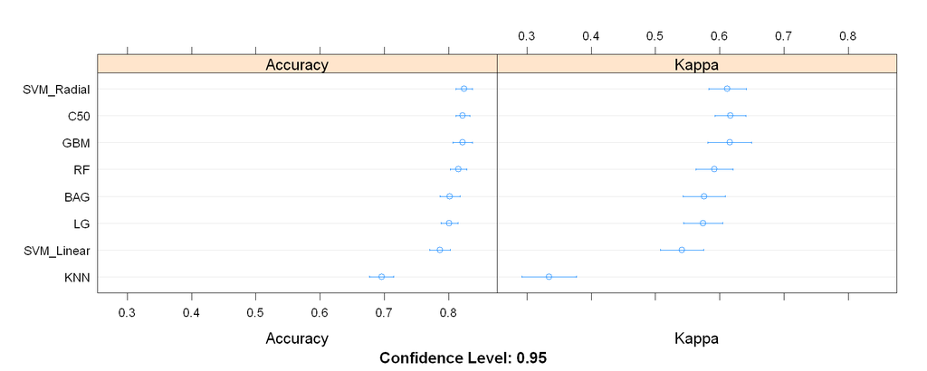

```r
set.seed(7)
fit.glm1 <- train(Survived~., data=train_tidy_ml, method="glm", metric=metric, trControl=trainControl)
fit.knn1 <- train(Survived~., data=train_tidy_ml, method="knn", metric=metric, trControl=trainControl)
fit.svm1 <- train(Survived~., data=train_tidy_ml, method="svmLinear", metric=metric,trControl=trainControl) # Support Vector Machines with Radial Linear Kernel
fit.svm2 <- train(Survived~., data=train_tidy_ml, method="svmRadial", metric=metric,trControl=trainControl) # Support Vector Machines with Radial Basis Function Kernel

# Bagging:
fit.treebag <- train(Survived~., data=train_tidy_ml, method="treebag", metric=metric,trControl=trainControl) # BAG: Bagged CART (Técnicas de bootstrap)
fit.rf <- train(Survived~., data=train_tidy_ml, method="rf", metric=metric,trControl=trainControl) # RF: Random Forest (Combina diversas árvores de decisão e adiciona um componente estocástico)
# Boosting:
fit.gbm <- train(Survived~., data=train_tidy_ml, method="gbm", metric=metric, trControl=trainControl, verbose=FALSE) # GBM: Stochastic Gradient Boosting (Extensão do Adaboost)
fit.c50 <- train(Survived~., data=train_tidy_ml, method="C5.0", metric=metric, trControl=trainControl) # C5.0

results <- resamples(list(LG=fit.glm1, KNN=fit.knn1, SVM_Linear=fit.svm1,SVM_Radial=fit.svm2,
                        BAG=fit.treebag, RF=fit.rf,
                        GBM=fit.gbm, C50=fit.c50))

dotplot(results)
```

# Otimização do Modelo - Ajuste de Hyperparâmetros

```r
grid <- expand.grid(.sigma=c(0.025, 0.05, 0.1, 0.15), .C=seq(1, 10, by=1))
fit.svm_final <- train(Survived~., data=train_tidy_ml, method="svmRadial", metric=metric, tuneGrid=grid, trControl=trainControl)
print(fit.svm_final)
```

```
Support Vector Machines with Radial Basis Function Kernel

891 samples
  8 predictor
  2 classes: 'bad', 'good'

No pre-processing
Resampling: Cross-Validated (10 fold, repeated 3 times)
Summary of sample sizes: 802, 801, 801, 802, 803, 802, ...
Resampling results across tuning parameters:

  sigma  C   Accuracy  Kappa
  0.025   1  0.810     0.587
  0.025   2  0.819     0.605
  0.025   3  0.816     0.597
  0.025   4  0.820     0.604
  0.025   5  0.820     0.603
  0.025   6  0.822     0.607
  0.025   7  0.820     0.602
  0.025   8  0.821     0.603
  0.025   9  0.821     0.604
  0.025  10  0.819     0.600
  0.050   1  0.816     0.596
  0.050   2  0.822     0.607
 [ reached getOption("max.print") -- omitted 28 rows ]

Accuracy was used to select the optimal model using the largest value.
The final values used for the model were sigma = 0.1 and C = 2.
```

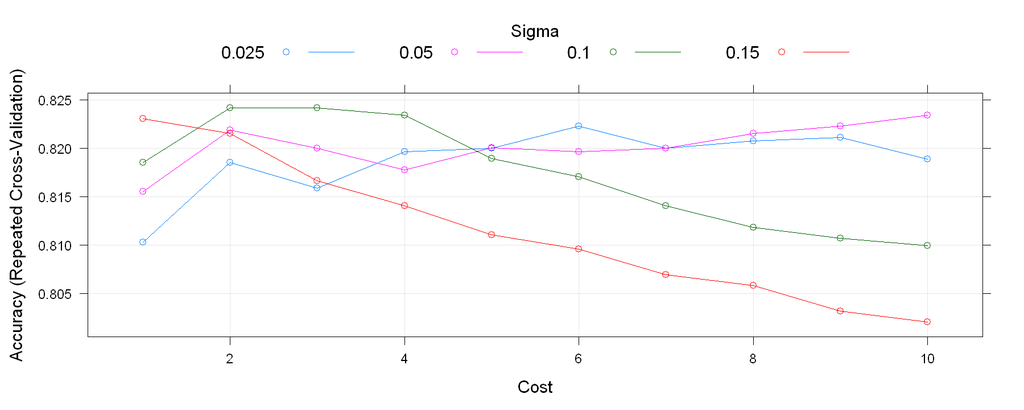

```r
plot(fit.svm_final)
```

# Split em treino e teste

```r
set.seed(1234)
indxTrain <- sample(1:dim(train_tidy_ml)[1], round(dim(train_tidy_ml)[1]*0.75,0))
train_final <- train_tidy_ml[indxTrain,]
test_final <- train_tidy_ml[-indxTrain,]
train_final %>% dim()
test_final %>% dim()
```

1. 668

2. 9

1. 223

2. 9

# Métricas para Algoritmos de Classificação

```r
train_final$predictions <- predict(object=fit.svm_final, newdata=train_final, type="raw")
test_final$predictions <- predict(object=fit.svm_final, newdata=test_final, type="raw")
```

```r
cM_train_final <- confusionMatrix(train_final$predictions, train_final$Survived)
cM_test_final <- confusionMatrix(test_final$predictions, test_final$Survived)
```

```r
cM_train_final
```

```
Confusion Matrix and Statistics

          Reference
Prediction bad good
      bad  188   24
      good  76  380

               Accuracy : 0.85
                 95% CI : (0.821, 0.877)
    No Information Rate : 0.605
    P-Value [Acc > NIR] : < 2e-16

                  Kappa : 0.676

 Mcnemar's Test P-Value : 3.4e-07

            Sensitivity : 0.712
            Specificity : 0.941
         Pos Pred Value : 0.887
         Neg Pred Value : 0.833
             Prevalence : 0.395
         Detection Rate : 0.281
   Detection Prevalence : 0.317
      Balanced Accuracy : 0.826

       'Positive' Class : bad
```

```r
cM_test_final
```

```
Confusion Matrix and Statistics

          Reference
Prediction bad good
      bad   50    7
      good  28  138

               Accuracy : 0.843
                 95% CI : (0.789, 0.888)
    No Information Rate : 0.65
    P-Value [Acc > NIR] : 1.05e-10

                  Kappa : 0.632

 Mcnemar's Test P-Value : 0.000723

            Sensitivity : 0.641
            Specificity : 0.952
         Pos Pred Value : 0.877
         Neg Pred Value : 0.831
             Prevalence : 0.350
         Detection Rate : 0.224
   Detection Prevalence : 0.256
      Balanced Accuracy : 0.796

       'Positive' Class : bad
```

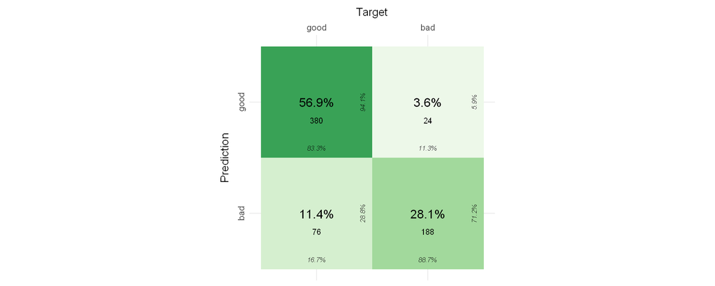

```r
cvms::plot_confusion_matrix(as_tibble(cM_train_final$table),
                      target_col = "Prediction",
                      prediction_col = "Reference",
                      counts_col = "n",
                      palette = "Greens")
```

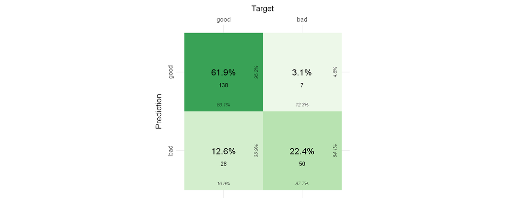

```r
cvms::plot_confusion_matrix(as_tibble(cM_test_final$table),
                      target_col = "Prediction",
                      prediction_col = "Reference",
                      counts_col = "n",
                      palette = "Greens")
```

```r
round(cbind(cM_overall_train_final=cM_train_final$overall,
        cM_overall_test_final=cM_test_final$overall),4)
```

A matrix: 7 × 2 of type dbl

|  | cM_overall_train_final | cM_overall_test_final |
| --- | --- | --- |
| Accuracy | 0.850 | 0.8430 |
| Kappa | 0.676 | 0.6321 |
| AccuracyLower | 0.821 | 0.7885 |
| AccuracyUpper | 0.876 | 0.8882 |
| AccuracyNull | 0.605 | 0.6502 |
| AccuracyPValue | 0.000 | 0.0000 |
| McnemarPValue | 0.000 | 0.0007 |

```r
round(cbind(cM_overall_train_final=cM_train_final$byClass,
        cM_overall_test_final=cM_test_final$byClass),4)
```

A matrix: 11 × 2 of type dbl

|  | cM_overall_train_final | cM_overall_test_final |
| --- | --- | --- |
| Sensitivity | 0.712 | 0.641 |
| Specificity | 0.941 | 0.952 |
| Pos Pred Value | 0.887 | 0.877 |
| Neg Pred Value | 0.833 | 0.831 |
| Precision | 0.887 | 0.877 |
| Recall | 0.712 | 0.641 |
| F1 | 0.790 | 0.741 |
| Prevalence | 0.395 | 0.350 |
| Detection Rate | 0.281 | 0.224 |
| Detection Prevalence | 0.317 | 0.256 |
| Balanced Accuracy | 0.826 | 0.796 |

# Salvando o resultado do seu trabalho

```r
saveRDS(fit.svm_final,file="modelo_classificador_final.rda")
```

```r
modelo_classificador_final <- readRDS(file="modelo_classificador_final.rda")
```

```r
modelo_classificador_final
```

```
Support Vector Machines with Radial Basis Function Kernel

891 samples
  8 predictor
  2 classes: 'bad', 'good'

No pre-processing
Resampling: Cross-Validated (10 fold, repeated 3 times)
Summary of sample sizes: 802, 801, 801, 802, 803, 802, ...
Resampling results across tuning parameters:

  sigma  C   Accuracy  Kappa
  0.025   1  0.810     0.587
  0.025   2  0.819     0.605
  0.025   3  0.816     0.597
  0.025   4  0.820     0.604
  0.025   5  0.820     0.603
  0.025   6  0.822     0.607
  0.025   7  0.820     0.602
  0.025   8  0.821     0.603
  0.025   9  0.821     0.604
  0.025  10  0.819     0.600
  0.050   1  0.816     0.596
  0.050   2  0.822     0.607
 [ reached getOption("max.print") -- omitted 28 rows ]

Accuracy was used to select the optimal model using the largest value.
The final values used for the model were sigma = 0.1 and C = 2.
```

```r
final_predict <- predict(modelo_classificador_final, newdata = test_tidy_ml, type = "raw")
final_predict <- ifelse(final_predict == 'bad',1,0)
final_predict
```

1. 0

2. 0

3. 0

4. 0

5. 0

6. 0

7. 1

8. 0

9. 1

10. 0

11. 0

12. 0

13. 1

14. 0

15. 1

16. 1

17. 0

18. 0

19. 0

20. 0

21. 0

22. 1

23. 1

24. 0

25. 1

26. 0

27. 1

28. 0

29. 0

30. 0

31. 0

32. 0

33. 0

34. 0

35. 1

36. 0

37. 0

38. 0

39. 0

40. 0

41. 0

42. 0

43. 0

44. 1

45. 1

46. 0

47. 0

48. 0

49. 1

50. 0

51. 0

52. 0

53. 1

54. 1

55. 0

56. 0

57. 0

58. 0

59. 0

60. 1

61. 0

62. 0

63. 0

64. 1

65. 0

66. 1

67. 1

68. 0

69. 1

70. 0

71. 1

72. 0

73. 0

74. 1

75. 1

76. 0

77. 0

78. 1

79. 0

80. 1

81. 1

82. 0

83. 0

84. 0

85. 0

86. 0

87. 1

88. 0

89. 1

90. 1

91. 0

92. 0

93. 1

94. 0

95. 0

96. 0

97. 1

98. 0

99. 0

100. 0

101. 1

102. 0

103. 0

104. 0

105. 1

106. 0

107. 0

108. 0

109. 0

110. 0

111. 0

112. 1

113. 1

114. 1

115. 1

116. 0

117. 0

118. 1

119. 1

120. 1

121. 1

122. 0

123. 1

124. 0

125. 0

126. 1

127. 0

128. 1

129. 0

130. 0

131. 0

132. 0

133. 0

134. 0

135. 0

136. 0

137. 0

138. 0

139. 0

140. 0

141. 0

142. 1

143. 0

144. 0

145. 0

146. 0

147. 0

148. 0

149. 0

150. 0

151. 1

152. 0

153. 0

154. 0

155. 0

156. 0

157. 1

158. 0

159. 0

160. 0

161. 1

162. 1

163. 1

164. 0

165. 0

166. 0

167. 0

168. 0

169. 1

170. 0

171. 0

172. 0

173. 0

174. 0

175. 0

176. 1

177. 1

178. 0

179. 1

180. 1

181. 0

182. 1

183. 1

184. 0

185. 1

186. 0

187. 1

188. 0

189. 0

190. 0

191. 0

192. 0

193. 0

194. 0

195. 1

196. 0

197. 1

198. 0

199. 0

200. 0

201. ...

202. 1

203. 0

204. 1

205. 0

206. 1

207. 0

208. 1

209. 1

210. 0

211. 1

212. 0

213. 0

214. 0

215. 1

216. 0

217. 0

218. 1

219. 0

220. 0

221. 0

222. 1

223. 1

224. 1

225. 1

226. 0

227. 0

228. 1

229. 0

230. 1

231. 0

232. 1

233. 0

234. 1

235. 0

236. 0

237. 0

238. 0

239. 0

240. 0

241. 0

242. 1

243. 0

244. 0

245. 0

246. 1

247. 1

248. 0

249. 0

250. 0

251. 0

252. 0

253. 0

254. 0

255. 0

256. 1

257. 1

258. 0

259. 1

260. 0

261. 0

262. 0

263. 0

264. 0

265. 1

266. 1

267. 1

268. 1

269. 0

270. 0

271. 0

272. 0

273. 0

274. 0

275. 1

276. 0

277. 0

278. 0

279. 0

280. 1

281. 0

282. 0

283. 0

284. 0

285. 0

286. 0

287. 0

288. 1

289. 1

290. 0

291. 1

292. 0

293. 0

294. 0

295. 0

296. 0

297. 1

298. 1

299. 1

300. 0

301. 0

302. 0

303. 0

304. 0

305. 0

306. 0

307. 0

308. 1

309. 0

310. 1

311. 0

312. 0

313. 0

314. 1

315. 1

316. 0

317. 1

318. 0

319. 0

320. 0

321. 0

322. 0

323. 0

324. 0

325. 0

326. 0

327. 1

328. 0

329. 0

330. 0

331. 0

332. 0

333. 1

334. 1

335. 0

336. 0

337. 0

338. 1

339. 0

340. 1

341. 0

342. 0

343. 0

344. 0

345. 1

346. 1

347. 0

348. 1

349. 0

350. 0

351. 0

352. 1

353. 0

354. 0

355. 1

356. 0

357. 0

358. 1

359. 1

360. 0

361. 0

362. 0

363. 0

364. 0

365. 0

366. 0

367. 0

368. 0

369. 1

370. 0

371. 0

372. 0

373. 0

374. 0

375. 1

376. 1

377. 0

378. 0

379. 1

380. 0

381. 1

382. 0

383. 0

384. 1

385. 0

386. 1

387. 0

388. 1

389. 0

390. 0

391. 0

392. 1

393. 1

394. 1

395. 1

396. 0

397. 0

398. 1

399. 0

400. 0

401. 1

```r
test <- read.csv("../../test.csv",
                 sep=",", stringsAsFactors = FALSE,
                 na.strings = "")
```

```r
predict_submission <- data.frame(PassengerId=test$PassengerId,Survived=final_predict)
#write.csv(predict_submission,'predict_submission.csv',row.names = FALSE,fileEncoding = "utf-8", quote = FALSE)
write_csv(predict_submission,'predict_submission.csv')
```

```r
predict_submission
```

A data.frame: 418 × 2

| PassengerId <int> | Survived <dbl> |
| --- | --- |
| 892 | 0 |
| 893 | 0 |
| 894 | 0 |
| 895 | 0 |
| 896 | 0 |
| 897 | 0 |
| 898 | 1 |
| 899 | 0 |
| ... | ... |
| 1303 | 1 |
| 1304 | 0 |
| 1305 | 0 |
| 1306 | 1 |
| 1307 | 0 |
| 1308 | 0 |
| 1309 | 1 |